# Exercise report on mixture model

Author

Mélanie FOURNIER

Published

September 11, 2024

# Exercise 3 - Towel data set

In this exercise we analyse the results of several experiments. The experiments are whether the inclusion of a message stating stating that most people reuse their towel in their hotel room made it more likely for guests to do so.

The dataset has the following variables:

- Source: the particular experiment.
- AuthorName: the name of the authors of the experiment
- Experiment: Some of the author repeated their experiment at a later date. This variable indicates which experiment is which.
- Year: The year the experiment was performed.
- Group: control group (the guest received a message about the ecological aspect of reusing towel) or Social(the guest received the social norm message).
- Towel.Reuse: Whether the guest reused the towel or not
- Count: the number of guests this concerned.

The relevant variables are Source, Group and Towel.Reuse.

There are in total 7 experiments that have been carried out, with an average of 642 guests per experiment.

```r
df2 <- read.csv2('towelData.csv')
head(df2) %>% kbl()
```

The data set

| Source | AuthorName | Experiment | Year | Group | Towel.Reuse | Count |
| --- | --- | --- | --- | --- | --- | --- |
| Goldstein.2008.Ex1 | Goldstein et al. | 1 | 2008 | Control | Yes | 74 |
| Goldstein.2008.Ex1 | Goldstein et al. | 1 | 2008 | Social Norm | Yes | 98 |
| Goldstein.2008.Ex1 | Goldstein et al. | 1 | 2008 | Control | No | 137 |
| Goldstein.2008.Ex1 | Goldstein et al. | 1 | 2008 | Social Norm | No | 124 |
| Goldstein.2008.Ex2 | Goldstein et al. | 2 | 2008 | Control | Yes | 103 |
| Goldstein.2008.Ex2 | Goldstein et al. | 2 | 2008 | Social Norm | Yes | 587 |

## Data visualization

Without making a single model, we can visualize the results of each experiments.

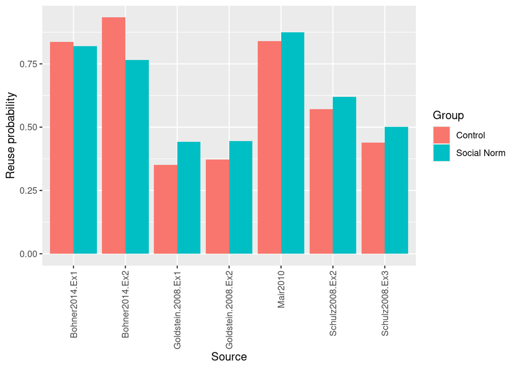

Towel reuse probability across the 7 experiments. One can see that there are a lot of changes in probability across experiment, and that the results are not the same across experiments.

We can see that there are quite a bit of variation in results across the experiments.

One approach would be to agregate the results of every experiments together, but this would not take into account the heterogeneity between experiments.

```r
df2 %>% group_by(Group,Towel.Reuse) %>%
  summarize(n = sum(Count)) %>% kbl()
```

By agregating all the experiments together, we can see that a bit more people reused their towel when the social norm message was used compared to control.

| Group | Towel.Reuse | n |
| --- | --- | --- |
| Control | No | 504 |
| Control | Yes | 508 |
| Social Norm | No | 1519 |
| Social Norm | Yes | 1963 |

## The model

In order to account to the fact that each experiment is run independently, there is an in group effect that is present. For example, some hotels may have a clientele that is more receptive to social norm pressure than other. This is modeled as a random effect. The fixed effects consist only of an intercept and which groups the participants where in.

The model is thus a general linear mixed model with a Bernoulli response variable: whether the towel was reused or not.

$$y_i \sim \text{bernoulli}(p(x_i))$$

with $logit(p(x_i)) = \beta_0 + \beta_1 \text{Group} + u_j$ where $u_j$ is a random effect taken from a normal distribution with a variance $\sigma^2$.

The model is fit with both the frequentist and the Bayesian approach to compare the results.

Some light re-coding of the variable is done to prepare them for the model:

```r
#Recoding for the model
df <- df2 %>% mutate(Towel.Reuse = recode(Towel.Reuse,
                                         'Yes' = 1,
                                         'No' = 0))
#Expanding every count to be their own observation.
df <- df %>% uncount(Count)
```

## Frequentist approach

The model is fit in the frequentist approach with the glmer function available in the lme4 library.

```r
model <- glmer(Towel.Reuse ~ Group + (1| Source) ,data = df,family = binomial)
summary(model)
```

```
Generalized linear mixed model fit by maximum likelihood (Laplace
  Approximation) [glmerMod]
 Family: binomial  ( logit )
Formula: Towel.Reuse ~ Group + (1 | Source)
   Data: df

     AIC      BIC   logLik deviance df.resid
  5760.8   5780.0  -2877.4   5754.8     4491

Scaled residuals:
    Min      1Q  Median      3Q     Max
-2.3110 -0.8905  0.4563  1.0006  1.2922

Random effects:
 Groups Name        Variance Std.Dev.
 Source (Intercept) 0.6876   0.8292
Number of obs: 4494, groups:  Source, 7

Fixed effects:
                 Estimate Std. Error z value Pr(>|z|)
(Intercept)       0.44792    0.32446   1.381  0.16743
GroupSocial Norm  0.21066    0.07731   2.725  0.00644 **
---
Signif. codes:  0 '***' 0.001 '**' 0.01 '*' 0.05 '.' 0.1 ' ' 1

Correlation of Fixed Effects:
            (Intr)
GroupSclNrm -0.169
```

The following code shows the 95% confidence intervals for the parameters.

```r
estimates <- c(0.829,0.448,0.211)
params <- bind_rows(model%>%
                confint()%>%
                as.data.frame(., rownames = rownames(.))%>% # convert matrix to dataframe
                tibble::rownames_to_column(var = "parameter")%>% # convert rownames to variable
                mutate('estimate' = estimates)) %>%
                mutate('parameter' = c('sigma','beta_0','beta_1'))
```

```
Computing profile confidence intervals ...
```

```r
params %>% kbl(digits = 2)
```

Fitted parameters for the frequentist model

| parameter | 2.5 % | 97.5 % | estimate |
| --- | --- | --- | --- |
| sigma | 0.51 | 1.60 | 0.83 |
| beta_0 | -0.27 | 1.20 | 0.45 |
| beta_1 | 0.06 | 0.36 | 0.21 |

The parameter $\beta_1$ is greater than 0 so there is an increased odd for guests to reuse their towel if a social norm message is shown to them. This results is statistically significant based on profile likelihood confidence intervals.

The variance $\sigma$ for the random effect is quite high, showing that there can be quite a disparity between studies for guests to reuse their towels with different probabilities.

## Bayesian approach

A Bayesian model can also be fit. The model is fit with the brms packages. The prior are chosen by the brms package, with the exception of $\beta_1 \sim \mathcal{N}(0,0.3)$.

```r
library(brms)

prior <- prior("normal(0,0.3)",class = "b", coef = "GroupSocialNorm")
model_bayes <- brm(Towel.Reuse ~ Group + (1| Source),
                  data = df,family = bernoulli(link='logit'),
                  chains = 4,
                  cores = 4,
                  backend = 'cmdstanr',
                  sample_prior = 'yes',
                  prior = prior,
                  seed = 1234)
```

The posteriors mean estimate and a 95% credible interval are shown in the table below:

```r
posterior_summary(model_bayes,variable = c('b_Intercept','b_GroupSocialNorm','sd_Source__Intercept')) %>% kbl(digits=3)
```

Posterior estimates for the parameters

|  | Estimate | Est.Error | Q2.5 | Q97.5 |
| --- | --- | --- | --- | --- |
| b_Intercept | 0.457 | 0.445 | -0.430 | 1.370 |
| b_GroupSocialNorm | 0.196 | 0.076 | 0.047 | 0.348 |
| sd_Source__Intercept | 1.116 | 0.409 | 0.587 | 2.228 |

In particular, the credible interval for the social norm is $[0.047,0.348]$ with a mean of $0.196$. These corresponds to an odd ratio of $1.21$ with CI $[1.05,1.41]$. Based on this, we can assume that switching to a social norm based message had an effect on the behaviors of the guests.

Standard plots for the model are shown here. In general, the chains show good mixing and the chains are stationary.

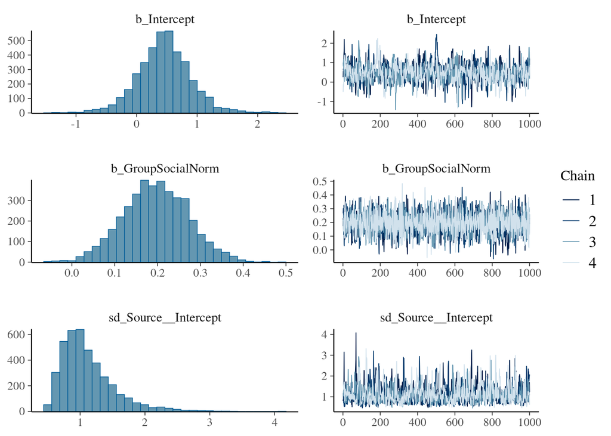

Posterior distribution samples histogram on the left. Associated Markov chain on the right. Almost all sample in b_GroupSocialNorm are greater than 0, visually confirming that the social norm message had an effect.

```r
plot(model_bayes)
```

Compared to the hypothesis that $\beta_1 = 0$, we have a Bayes factor of 7.83, showing weak evidence in favor of the $\beta_1 \neq 0$ hypothesis.

```r
hyp_test <- hypothesis(model_bayes,"GroupSocialNorm=0")
print(hyp_test)
```

```
Hypothesis Tests for class b:
             Hypothesis Estimate Est.Error CI.Lower CI.Upper Evid.Ratio
1 (GroupSocialNorm) = 0      0.2      0.08     0.05     0.35       0.13
  Post.Prob Star
1      0.11    *
---
'CI': 90%-CI for one-sided and 95%-CI for two-sided hypotheses.
'*': For one-sided hypotheses, the posterior probability exceeds 95%;
for two-sided hypotheses, the value tested against lies outside the 95%-CI.
Posterior probabilities of point hypotheses assume equal prior probabilities.
```

```r
#The Bayes factor is then the inverse of the Evid.Ratio variable
bayes_factor <- 1/hyp_test$hypothesis['Evid.Ratio']
print(bayes_factor)
```

```
  Evid.Ratio
1   7.831878
```

Both the Bayesian and the Frequentist models reach the same conclusion that there is an effect, albeit quite small, due to the inclusion of a social norm message in terms of towel reuse probability. The heterogeneity between studies is quite big, and was addressed by adding the random effect.